# Análise Covid-19 - Minas Gerais

Grupo 05

30/07/2020

## Introdução Com a Pademia do Covid-19, o mapeamento do perfil das vítimas contaminadas tem sido essencial para fundamentar as estratégias de combate ao novo coronavírus pelos entes públicos. No Brasil, o primeiro caso confirmado deu-se no dia 26 de fevereiro e o primeiro óbito no dia 17 de março. No mundo, os primeiros óbitos foram registrados oficalmente em janeiro, permitindo que o Brasil pudesse se antecipar para reduzir a velocidade de contágio dentro do país. Embora o novo coronavírus ainda esteja sob pesquisa, sabe-se que pessoas acima de 60 anos e pessoas portadoras de comorbidade têm mais chances de terem seus quadros agravados pela doença. Nesse sentido, este relatório tem o objetivo de analisar os dados da Covid-19 em Minas Gerais. Os dados foram extraídos no dia 13/07/2020 do [site](http://coronavirus.saude.mg.gov.br/painel) da Secretaria de Saúde do estado. O escopo da análise foi comparar a contaminação e evolução do novo coronavírus segundo a faixa-etária, comorbidade, gênero e região do estado. Quanto à região, optou-se por comparar as macro regiões do norte de Minas Gerais com a região metropolitana. Dessa forma, buscou-se responder 5 perguntas: (i) o perfil da curva de crescimento (número de casos acumulados) na população com idade a partir de 60 ano; (ii) a associação entre comorbidades e a evolução do quadro clínico; (iii) diferenciação entre os sexos no que se relaciona à evolução do quadro clínico; (iv) diferenciação entre as faixas-etárias no que se relaciona à evolução do quadro clínico; e (v) se municípios no norte e nordeste de MG possuem piores evolução dos quadros clínicos em comparação com Belo Horizonte e suas regionais.

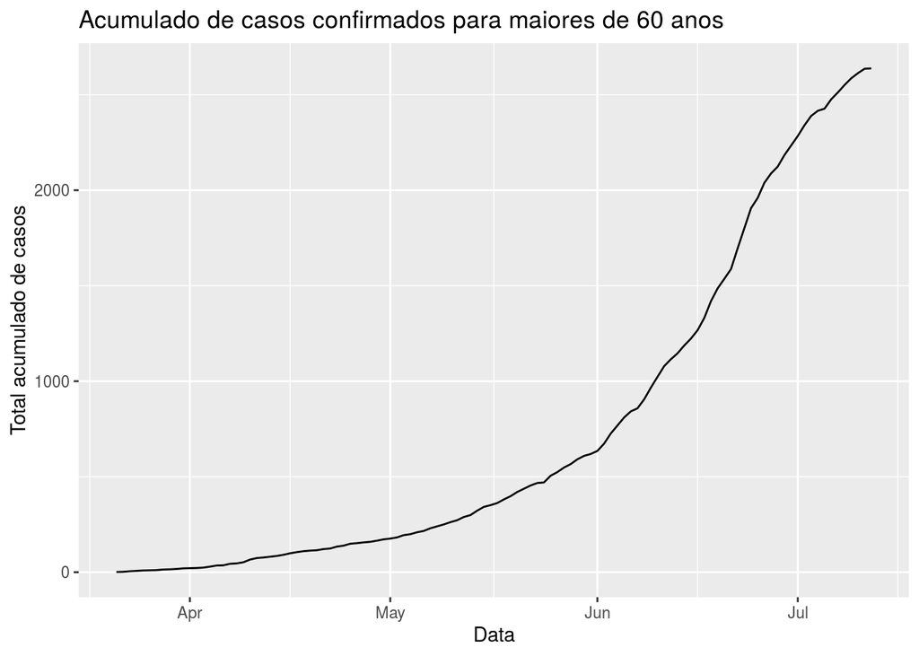

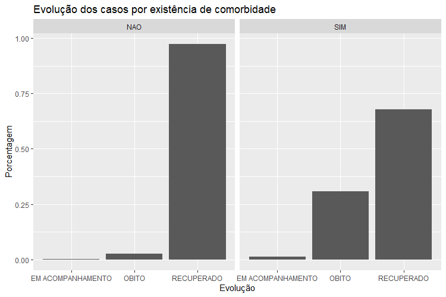

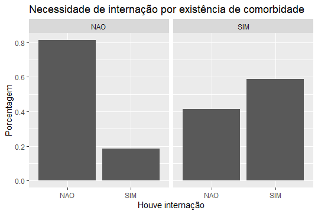

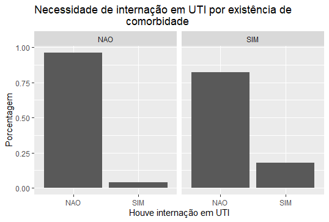

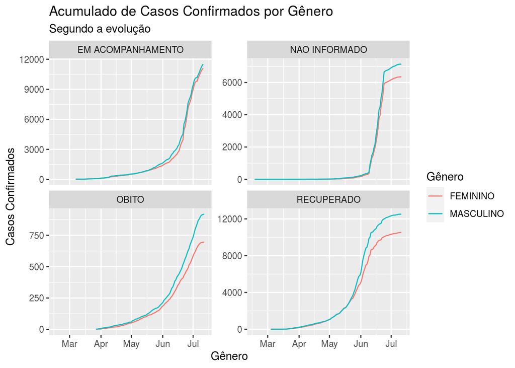

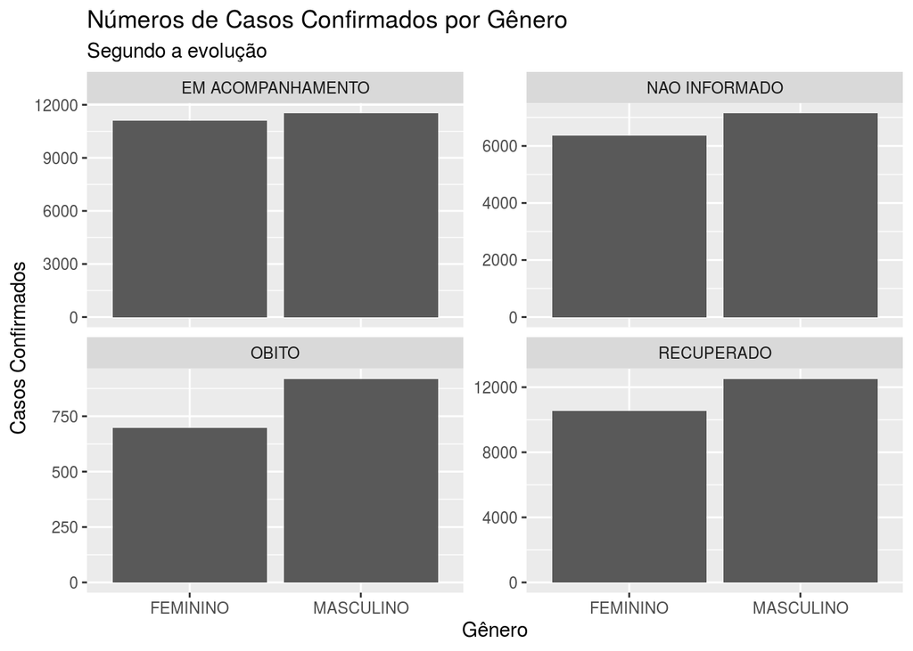

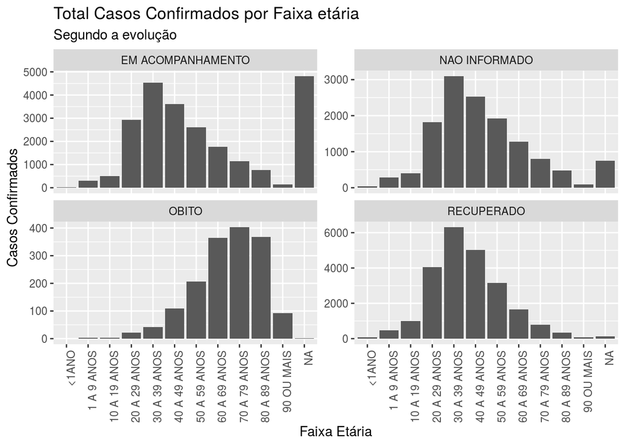

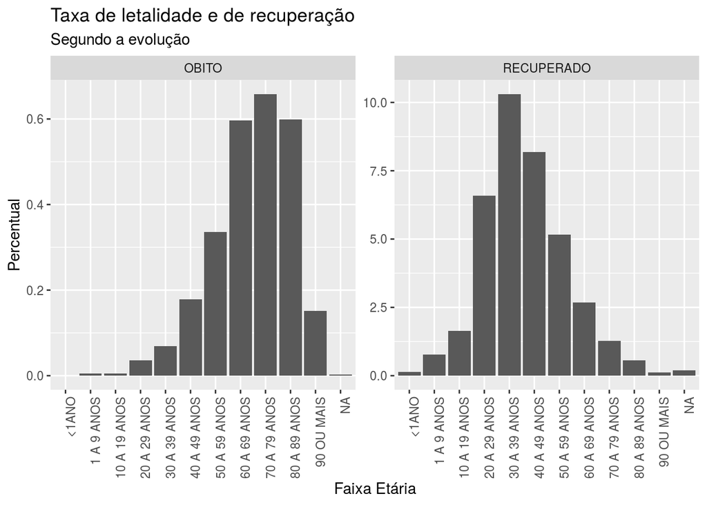

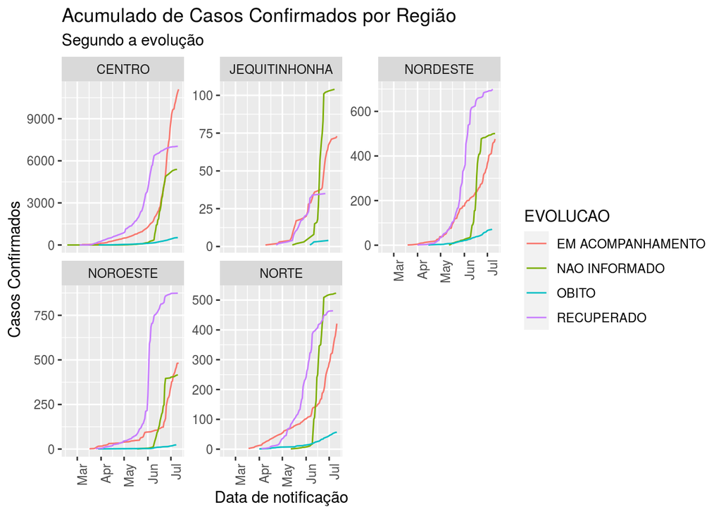